# Visualizing Epigenomic Big Data Using genomation and Gviz R/Bioconductor packages

David Chen (github.com/ydavidchen)

12/14/2016

## Overview

In this tutorial, we will practice visualization of two types of high-throughput epigenomics data: DNA methylation and chromatin modification. The **Roadmap Epigenomics** project provides high-quality data sets for our data visualization exercise. Several such data sets have been collected on the **CD3 primary cells**:

- DNA methylation by Reduced Representation Bisulfite Sequencing (RRBS)
- Chromatin modification (specifically, H3K27ac, collected by chromatin immuno precipitation followed by deep sequencing, ChIP-seq)

To learn more about these biotechnologies, please refer to **Park PJ. Nat. Rev.Genet. 10 (2009)** and **Bock C Nat. Rev. Genet. 13 (2012)**.

To be able to follow along this tutorial, you should have a strong grasp of the R programming language and experience with Bioconductor tools. You should also be familiar with `GenomicRanges` operations. Linux/Unix is not required for this tutorial.

## Data Source

You may access the Roadmap Epigenomics metadata (a Google spreadsheet) to identify samples. Here, we see that files labeled $E33$ or $E34$ are from the CD3 cell line:

```r
# install.packages("gsheet")
library(gsheet)
metaData <- gsheet2tbl("https://docs.google.com/spreadsheet/ccc?key=0Am6FxqAtrFDwdHU1UC13ZUxKYy1XVEJPUzV6MEtQOXc&usp=sharing#gid=15")
```

Download the CD3 data sets directly from **Roadmap Epigenomics** web portal. Alternatively, you can manually fetch those files from [Roadmap Epigenomics](http://egg2.wustl.edu/roadmap/web_portal/) or [Gene Expression Omnibus](https://www.ncbi.nlm.nih.gov/geo/roadmap/epigenomics/) and then load into R using `rtracklayer::import`.

```r
# source("https://bioconductor.org/biocLite.R")
# biocLite(c("rtracklayer", "GenomicRanges"))
library(rtracklayer)
library(GenomicRanges)

## Speed up computation by using multiple cores:
# install.packages("doParallel")
library(doParallel)
registerDoParallel(detectCores() - 1)

## Download & import RRBS methylation data set as GRanges object:
CD3_rrbs_path <- "http://egg2.wustl.edu/roadmap/data/byDataType/dnamethylation/RRBS/FractionalMethylation_bigwig/E033_RRBS_FractionalMethylation.bigwig"
CD3_rrbs <- import.bw(CD3_rrbs_path)
CD3_rrbs
```

```
## GRanges object with 2054524 ranges and 1 metadata column:
##             seqnames               ranges strand |             score
##                <Rle>            <IRanges>  <Rle> |         <numeric>
##         [1]     chr1       [10497, 10497]      * | 0.779999971389771
##         [2]     chr1       [10498, 10498]      * | 0.779999971389771
##         [3]     chr1       [10525, 10525]      * | 0.959999978542328
##         [4]     chr1       [10526, 10526]      * | 0.959999978542328
##         [5]     chr1       [10589, 10589]      * | 0.629999995231628
##         ...      ...                  ...    ... .               ...
##   [2054520]     chrY [28773388, 28773388]      * | 0.720000028610229
##   [2054521]     chrY [28773390, 28773390]      * | 0.360000014305115
##   [2054522]     chrY [28773391, 28773391]      * | 0.360000014305115
##   [2054523]     chrY [59026010, 59026010]      * |                 1
##   [2054524]     chrY [59026011, 59026011]      * |                 1
##   -------
##   seqinfo: 24 sequences from an unspecified genome
```

```r
## Download & import histone .broadPeak data as GRanges object (standard approach):
CD3_H3K27ac_path <- "http://egg2.wustl.edu/roadmap/data/byFileType/peaks/consolidated/broadPeak/E034-H3K27ac.broadPeak.gz"

## Select columns (if your data file to read is narrowPeak, add `peak = "integer"` to the vector):
extraCols <- c(singnalValue="numeric", pValue="numeric", qValue="numeric")
CD3_broadPeak <- import(CD3_H3K27ac_path, format="BED", extraCols=extraCols)
CD3_broadPeak
```

```
## GRanges object with 254902 ranges and 5 metadata columns:
##            seqnames                 ranges strand |        name     score
##               <Rle>              <IRanges>  <Rle> | <character> <numeric>
##        [1]    chr22 [ 30830312,  30833437]      * |      Rank_1      1305
##        [2]     chr1 [119680864, 119684595]      * |      Rank_2      1291
##        [3]    chr12 [ 62993769,  62999697]      * |      Rank_3      1246
##        [4]     chr7 [  2391959,   2394492]      * |      Rank_4      1246
##        [5]    chr17 [  7737005,   7749993]      * |      Rank_5      1233
##        ...      ...                    ...    ... .         ...       ...
##   [254898]     chr8 [140463463, 140463941]      * | Rank_254898         0
##   [254899]     chr8 [ 24551173,  24551528]      * | Rank_254899         0
##   [254900]     chr8 [ 28939866,  28940160]      * | Rank_254900         0
##   [254901]     chr8 [ 91949037,  91949290]      * | Rank_254901         0
##   [254902]     chr8 [ 92272655,  92273007]      * | Rank_254902         0
##            singnalValue    pValue    qValue
##               <numeric> <numeric> <numeric>
##        [1]     25.35399  133.5165  130.5939
##        [2]     20.97918  132.1079  129.1371
##        [3]     24.80344  127.4916  124.6028
##        [4]     19.76957  127.4696  124.6607
##        [5]     24.73676  126.2477  123.3294
##        ...          ...       ...       ...
##   [254898]      1.45773   1.00144         0
##   [254899]      1.45773   1.00144         0
##   [254900]      1.45773   1.00144         0
##   [254901]      1.45773   1.00144         0
##   [254902]      1.45773   1.00144         0
##   -------
##   seqinfo: 25 sequences from an unspecified genome; no seqlengths
```

As an exercise, we will be examining the chromatin and DNA-methylation landscape on chromosome X (chrX).

```r
CD3_rrbs <- CD3_rrbs[seqnames(CD3_rrbs) == "chrX"]
CD3_broadPeak <- CD3_broadPeak[seqnames(CD3_broadPeak) == "chrX"]

CD3_rrbs@elementMetadata$CommonCol <- CD3_rrbs@elementMetadata$score #common column
CD3_rrbs@elementMetadata$score <- NULL
CD3_rrbs #preview
```

```
## GRanges object with 43732 ranges and 1 metadata column:
##           seqnames                 ranges strand | CommonCol
##              <Rle>              <IRanges>  <Rle> | <numeric>
##       [1]     chrX     [2700608, 2700608]      * |         1
##       [2]     chrX     [2700609, 2700609]      * |         1
##       [3]     chrX     [2720584, 2720584]      * |         1
##       [4]     chrX     [2720585, 2720585]      * |         1
##       [5]     chrX     [2720588, 2720588]      * |         1
##       ...      ...                    ...    ... .       ...
##   [43728]     chrX [154842679, 154842679]      * |         0
##   [43729]     chrX [154842689, 154842689]      * |         0
##   [43730]     chrX [154842690, 154842690]      * |         0
##   [43731]     chrX [154842704, 154842704]      * |         0
##   [43732]     chrX [154842705, 154842705]      * |         0
##   -------
##   seqinfo: 24 sequences from an unspecified genome
```

```r
CD3_broadPeak@elementMetadata$CommonCol <- CD3_broadPeak@elementMetadata$singnalValue #common column
CD3_broadPeak@elementMetadata$singnalValue <- NULL
CD3_broadPeak@elementMetadata$name <- NULL
CD3_broadPeak@elementMetadata$score <- NULL
CD3_broadPeak@elementMetadata$pValue <- NULL
CD3_broadPeak@elementMetadata$qValue <-NULL
CD3_broadPeak #preview
```

```
## GRanges object with 3458 ranges and 1 metadata column:
##          seqnames                 ranges strand | CommonCol
##             <Rle>              <IRanges>  <Rle> | <numeric>
##      [1]     chrX [148620439, 148623703]      * |  19.97349
##      [2]     chrX [ 15692496,  15695076]      * |  19.10202
##      [3]     chrX [123092838, 123099737]      * |  17.47131
##      [4]     chrX [ 53739675,  53746449]      * |  17.98357
##      [5]     chrX [110923448, 110926407]      * |  16.93094
##      ...      ...                    ...    ... .       ...
##   [3454]     chrX [131116816, 131117145]      * |   1.52655
##   [3455]     chrX [ 81045883,  81046062]      * |    1.5178
##   [3456]     chrX [154983125, 154983482]      * |   1.51206
##   [3457]     chrX [155169618, 155169875]      * |   1.49874
##   [3458]     chrX [  2289434,   2289654]      * |   1.50646
##   -------
##   seqinfo: 25 sequences from an unspecified genome; no seqlengths
```

Define transcription start using Bioconductor’s annotation package, which is based on the UCSC hg19 database. Note that if you prefer to fetch the annotation using a different method (e.g. `AnnotationHub` in R) or manually from the website, you are welcome to do so.

```r
# source("https://bioconductor.org/biocLite.R")
# biocLite("TxDb.Hsapiens.UCSC.hg19.knownGene")
library(TxDb.Hsapiens.UCSC.hg19.knownGene) #annotation package
myPromoters <- promoters(TxDb.Hsapiens.UCSC.hg19.knownGene, upstream=500, downstream=500) #adjust as necessary
```

## Genome-scale data visualization by genomation

Use the genomation package to plot a heat matrix for the RRBS

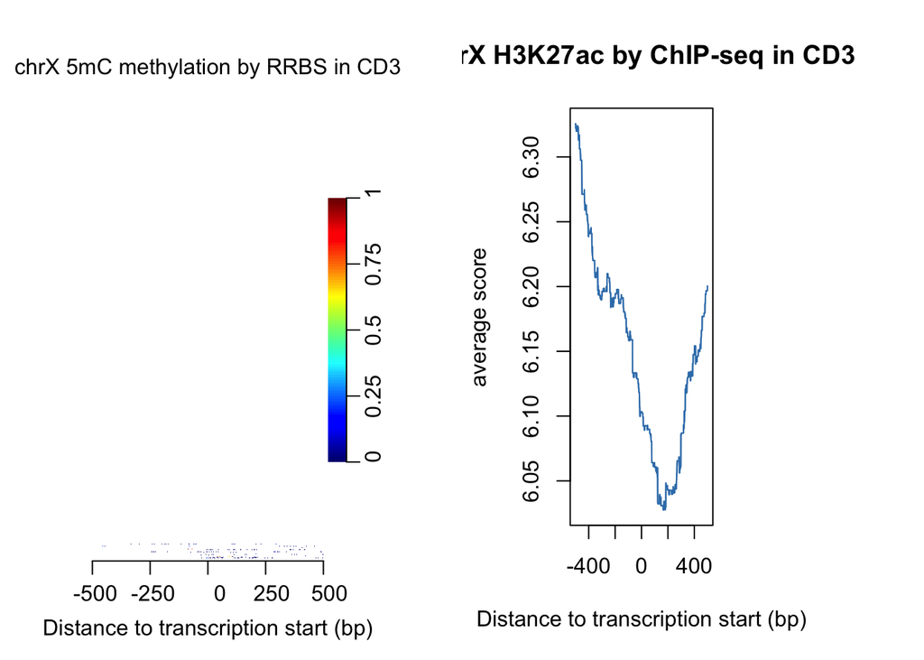

```r
# source("https://bioconductor.org/biocLite.R")
# biocLite(c("genomation"))
library(genomation)

## Define colors:
# install.packages("RColorBrewer")
library(RColorBrewer)
myCols <- brewer.pal(9, "Set1")

mySMlist <- ScoreMatrixList(
  targets = list(RRBS=CD3_rrbs, H3K27ac=CD3_broadPeak),
  windows = myPromoters,
  strand.aware = TRUE,
  weight.col = "CommonCol",
  is.noCovNA = TRUE #REQUIRED for data without complete coverage, like methylation
)

par(mfrow=c(1,2))

## Heat matrix for RRBS data:
heatMatrix(mySMlist[[1]], xcoords=c(-500, 500), xlab="Distance to transcription start (bp)", main = "chrX 5mC methylation by RRBS in CD3")

## Genomic Curve for H3K27ac data:
plotMeta(mySMlist[[2]], line.col=myCols[2], xcoords=c(-500, 500), xlab="Distance to transcription start (bp)", main="chrX H3K27ac by ChIP-seq in CD3")
```

## Single-gene-level data visualization using `Gviz`

Gviz is a `grid`-based package that generates publication-quality genomic plots. In this tutorial, we will examine the use of Gviz for visualizing H3K27ac and DNA methylation at two adjacent loci on the X chromosome

```r
library(Gviz)
myFavoriteGene <- c("EIF2S3", "KLHL15") #c("GENE1", "GENE2", ...)
gen <- "hg19" #genome build
chr <- "chrX"
```

Download gene and chromosome annotations from the UCSC hg19 database:

```r
mySession <- browserSession('UCSC')
genome(mySession) <- gen
query <- ucscTableQuery(mySession,track='refGene')
tableName(query) <- "refGene"
refseq <- getTable(query)

## Subset your tracks and tables as much as you can to save time and minimize RStudio crashing:
refseq <- refseq[refseq$name2 == myFavoriteGene, ] #further subset
TSS <- min(refseq$txStart)
from <- TSS - 5000 #add 5kb extra
to <- max(refseq$cdsEnd) + 5000 #add 5kb extra
paste0(chr,":",from,"-",to) #can be searched on UCSC Genome Broswer
```

```
## [1] "chrX:23996832-24099902"
```

Make track objects for chromosome band and genomic axis:

```r
ideoTrack <- IdeogramTrack(genome=gen, chromosome=chr, from=from, to=to)
axTrack <- GenomeAxisTrack(genome=gen, chromosome=chr, from=from, to=to)
```

Create a gene-region track using the RefSeq annotation:

```r
GeneTrack <- UcscTrack(
  genome=gen, chromosome=chr,
  track="refGene", trackType = "GeneRegionTrack",
  from=from, to=to,
  rstarts="exonStarts", rends="exonEnds", strand="strand",
  gene="name", symbol="name2", transcript="name",
  transcriptAnnotation="symbol", #labels gene names
  stacking="dense", #options: "full", "pack", & "dense" as in UCSC Genome Browser
  fill="salmon", col="salmon", name="RefSeq Genes" #update based on your choice
)
```

Use your data sets to make `DataTrack` objects:

```r
dTrack_RRBS <- DataTrack(
  CD3_rrbs,
  type="histogram",
  genome=gen, chromosome=chr,
  from=from, to=to,
  fill="blue", col="blue",
  name="RRBS"
)
dTrack_RRBS
```

```
## DataTrack 'RRBS'
## | genome: hg19
## | active chromosome: chrX
## | positions: 43732
## | samples:1
## | strand: *
```

```r
dTrack_H3K27ac <- DataTrack(
  CD3_broadPeak,
  type="histogram",
  genome=gen, chromosome=chr,
  from=from, to=to,
  fill="orange", col="orange",
  name="H3K27ac"
)
dTrack_H3K27ac
```

```
## DataTrack 'H3K27ac'
## | genome: hg19
## | active chromosome: chrX
## | positions: 3458
## | samples:1
## | strand: *
```

You may include additional tracks that represent (epi)genomic information. The syntax is identical to the gene-region track:

```r
cpgIslands <- UcscTrack(
  genome=gen, chromosome=chr, track="cpgIslandExt",
  from=from, to=to,
  trackType="AnnotationTrack",
  start="chromStart",
  end="chromEnd",
  id="name", shape="box",
  stacking="dense",
  fill="#006400", col="#006400", name="CpG islands"
)
```

You are now ready to plot the track objects:

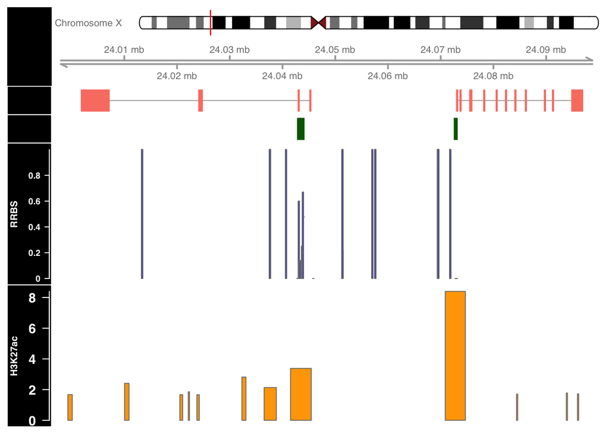

```r
plotTracks(
  c(ideoTrack, axTrack, GeneTrack, cpgIslands, dTrack_RRBS, dTrack_H3K27ac),
  genome=gen, chromosome=chr,
  reverseStrand=FALSE,
  from=from, to=to,
  background.title = "black"
)
```

A separate tutorial is written on how to visualize methylation array data.

## Summary

If you plan to revisit your plots, it might be a good idea to save your workspace. As you may have seen, generating these plots is computationally intensive and therefore time consuming.

```r
storagePath <- "" #Type your path here
save(list=ls(all.names=TRUE), file=paste(storagePath, "my-genomic-data-vis-workspace.RData", sep="/"))
```

## References

**Akalin, A. et al.** genomation: a toolkit to summarize, annotate, and visualize genomic intervals. Bioinfo 31(7): 1127-1129 (2015).

**Bock, C.** Analyzing and interpreting DNA methylation Data. Nature Rev. Genet. 13: 705-719 (2012).

**Hahne F, Ivanek R.** Visualizing genomic data using Gviz and Bioconductor. Methods Mol. Biol. 1418: 335-351 (2016)

**Park, PJ.** ChIP-seq: advantages and challenges of a maturing technology. Nature Rev. Genet. 10: 669-680 (2009).

**Roadmap Epigenomic Consortium, et al.** Integrative analysis of 111 reference human epigenomes. Nature 518: 317-330 (2015).